# Laboratory 2 - Maps

## 2.1 Polygon Maps

We take data from the `maps` package using `ggplot2::map_data()`. The `maps` package isn’t particularly accurate or up-to-date, but it’s built into R so it’s an easy place to start. Here’s a data set specifying the county boundaries for Michigan:

```r
mi_counties <- map_data("county", "michigan") %>%
  select(long, lat, group, id = subregion)
head(mi_counties)
```

|  | long | lat | group | id |
| --- | --- | --- | --- | --- |
| 1 | -83.88675 | 44.85686 | 1 | alcona |
| 2 | -83.36536 | 44.86832 | 1 | alcona |
| 3 | -83.36536 | 44.86832 | 1 | alcona |
| 4 | -83.33098 | 44.83968 | 1 | alcona |
| 5 | -83.30806 | 44.80530 | 1 | alcona |
| 6 | -83.30233 | 44.77665 | 1 | alcona |

`lat` and `long` specify the latitude and longitude of a vertex (i.e. a corner of the polygon), `id` specifies the name of a region, and `group` provides a unique identifier for contiguous areas within a region (e.g. if a region consisted of multiple islands).

We can plot `mi_counties` using `geom_point()`:

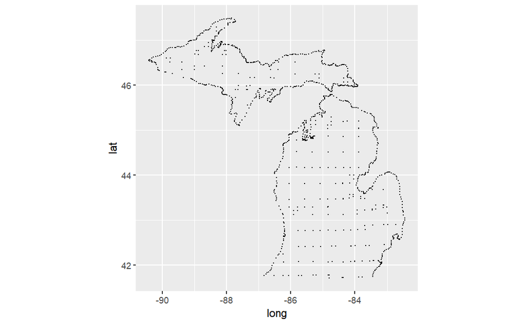

```r
ggplot(mi_counties, aes(long, lat)) +
  geom_point(size = .25, show.legend = FALSE) +
  coord_quickmap()
```

To turn this scatterplot into a map, we use `geom_polygon()` instead, which draws each county as a distinct polygon.

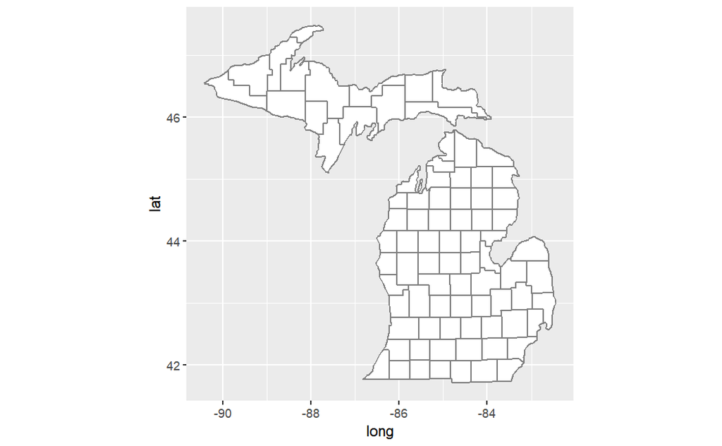

```r
ggplot(mi_counties, aes(long, lat, group = group)) +
  geom_polygon(fill = "white", colour = "grey50") +
  coord_quickmap()
```

## 2.2 Simple Features Maps

The simple “longitude-latitude” data format is not typically used in real world mapping. Vector data for maps are typically encoded using the **simple features** standard produced by the Open Geospatial Consortium. The `sf` package (Pebesma 2018) developed by Edzer Pebesma https://github.com/r-spatial/sf provides an excellent toolset for working with such data, and the `geom_sf()` and `coord_sf()` functions in `ggplot2` are designed to work together with the `sf` package.

To introduce these functions, we rely on the `ozmaps` package by Michael Sumner https://github.com/mdsumner/ozmaps/ which provides maps for Australian state boundaries, local government areas, electoral boundaries, and so on.

```r
library(ozmaps)
library(sf)

ozmap_states
```

```
Simple feature collection with 9 features and 1 field
Geometry type: MULTIPOLYGON
Dimension:     XY
Bounding box:  xmin: 105.5507 ymin: -43.63203 xmax: 167.9969 ymax: -9.229287
Geodetic CRS:  GDA94
```

|  | NAME | geometry |
| --- | --- | --- |
| 1 | New South Wales |  |
| 2 | Victoria |  |
| 3 | Queensland |  |
| 4 | South Australia |  |
| 5 | Western Australia |  |
| 6 | Tasmania |  |
| 7 | Northern Territory |  |
| 8 | Australian Capital Territory |  |
| 9 | Other Territories |  |

The `ozmap_states` dataset has 9 rows and 2 columns. One advantage to `sf` data is that we can easily see the overall structure of the data: Australia is comprised of 9 geographical units.

We can use `geom_sf()` and `coord_sf()` to draw a serviceable map:

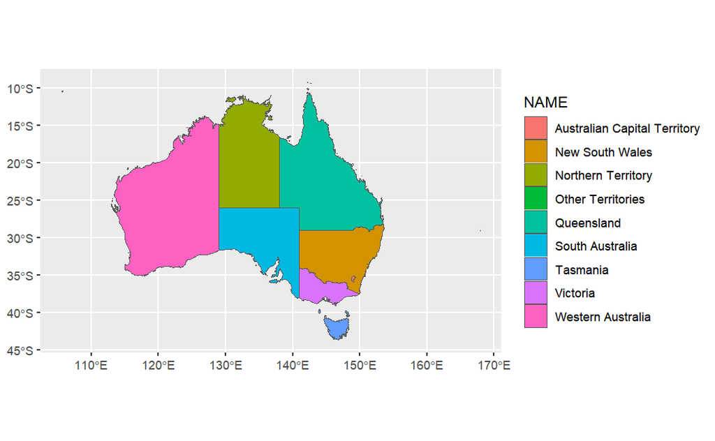

```r
ggplot() +
  geom_sf(data=ozmap_states, aes(fill=NAME)) +
  coord_sf()
```

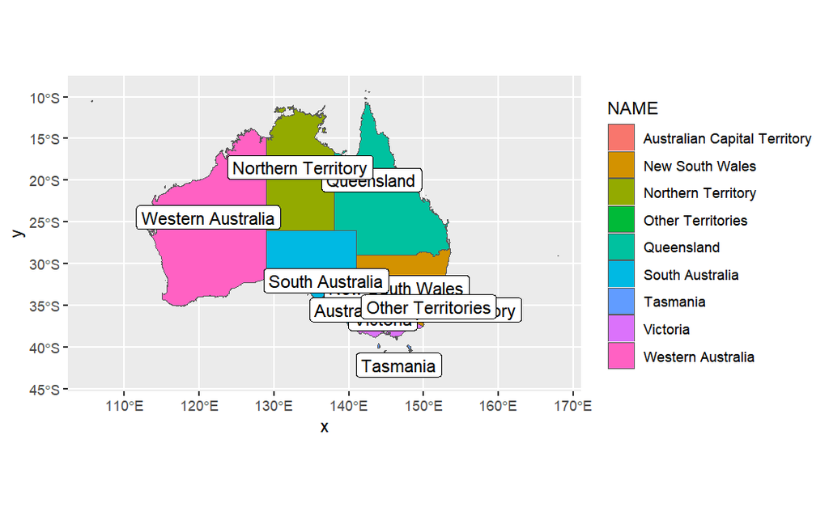

```r
ggplot() +
  geom_sf(data=ozmap_states, aes(fill=NAME)) +
  geom_sf_label(data=ozmap_states, aes(label=NAME)) +
  coord_sf()
```

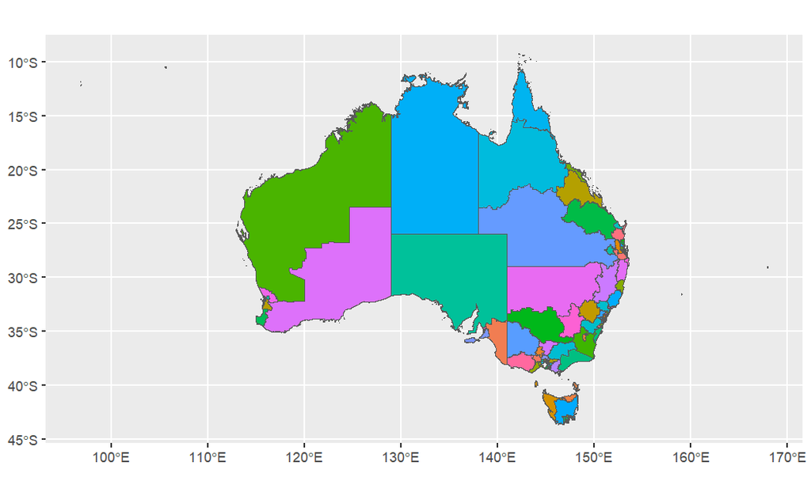

```r
ggplot() +
#  geom_sf(data=ozmap_states) +
  geom_sf(data=abs_ced, aes(fill=NAME), show.legend=FALSE) +
  coord_sf()
```

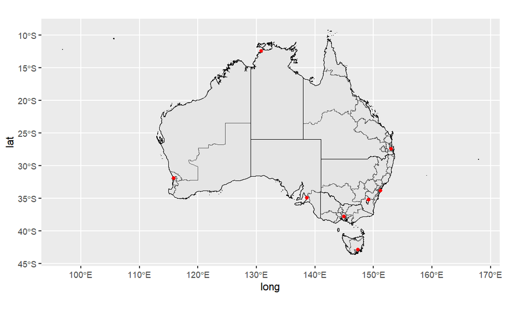

```r
oz_capitals <- data.frame(
  city = c("Sydney", "Melbourne", "Brisbane", "Adelaide", "Perth", "Hobart", "Canberra", "Darwin"),
  lat  = c(-33.8688, -37.8136, -27.4698, -34.9285, -31.9505, -42.8821, -35.2809, -12.4634),
  long = c(151.2093, 144.9631, 153.0251, 138.6007, 115.8605, 147.3272, 149.1300, 130.8456)
)

ggplot() +
  geom_sf(data = abs_ced) +
  geom_sf(data = ozmap_states, colour = "black", fill = NA) +
  geom_point(data = oz_capitals, mapping = aes(x = long, y = lat), colour = "red") +
  coord_sf()
```

## 2.3 Maps in China

`mapchina` is an excellent, specialized R package designed specifically for mapping China’s administrative divisions. It includes a 3-level geographic hierarchy: Province (2-digit), Prefecture (4-digit), and County (6-digit) codes. You can learn more about the package at https://github.com/xmc811/mapchina.

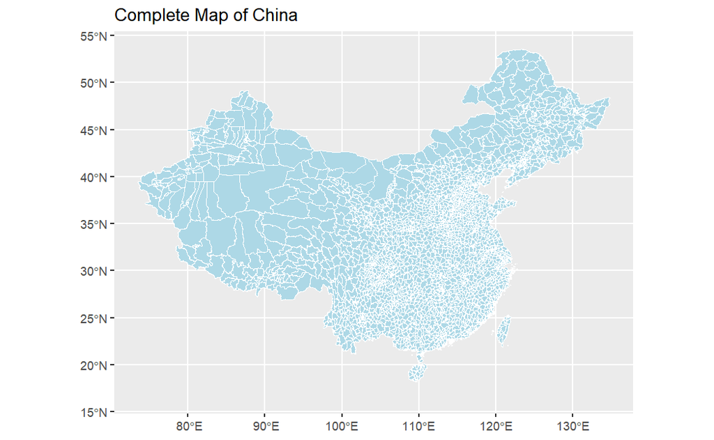

```r
# Install and load the package
# install.packages("mapchina")
library(mapchina)
# library(ggplot2)
# library(sf)
# library(dplyr)

# 1. Load the main spatial dataset
# This contains a dataframe named 'china'
data("china")

# 2. Plot the entire country (County/District level)
ggplot(data = china) +
  geom_sf(fill = "lightblue", color = "white", size = 0.1) +
  coord_sf() +
  labs(title = "Complete Map of China")
```

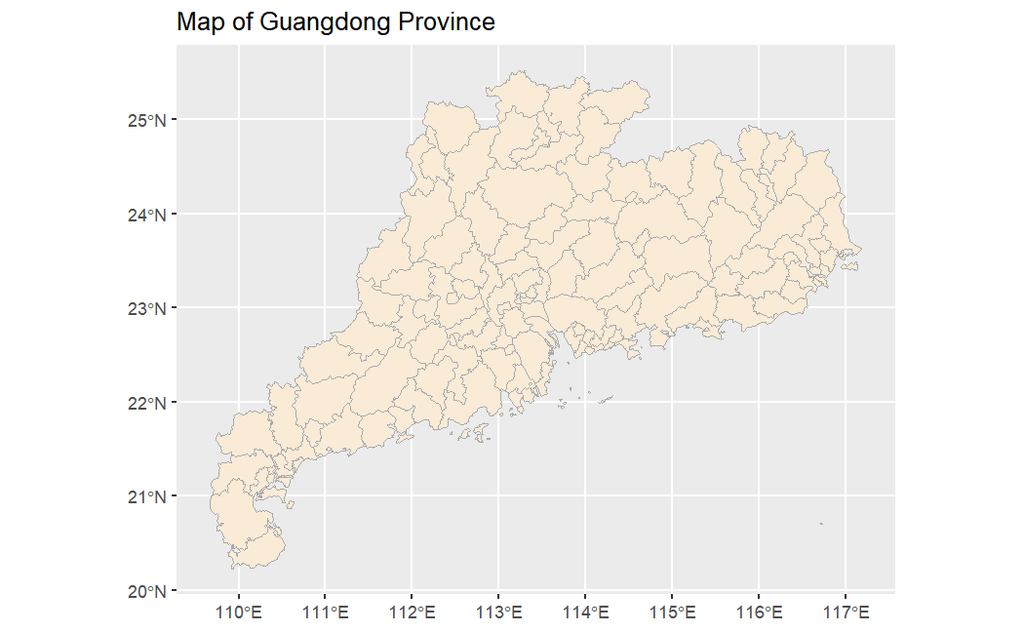

```r
# 3. Filter for a specific province (e.g., Guangdong)
guangdong_map <- china %>%
  filter(Name_Province == "广东省")

ggplot(data = guangdong_map) +
  geom_sf(fill = "antiquewhite", color = "darkgray") +
  coord_sf() +
  labs(title = "Map of Guangdong Province")
```